# Oxygen-16 geometry: a visual and numerical audit

This notebook follows the current geometry engine from **nucleon positions in three dimensions** to **hotspots, Gaussian densities, and longitudinally integrated thickness**. It compares the tetrahedral alpha model with the spherical three-parameter Fermi model. “WS / 3pF” below means the repository's `O16_3PF`: its nonzero $w$ makes it a three-parameter Fermi profile, rather than a two-parameter Woods–Saxon profile.

Run all cells after changing the geometry code. Every physics sample and field evaluation calls `upcmodel`; notebook helpers handle plotting, numerical integration, and independent diagnostics. The fixed seed and exported samples make a suspicious event reproducible. Changing a view never resamples it.

**Reading guide**

1. Parameters, units, and the input radial distribution.
2. Tetrahedral construction and rotations; 3D events and 2D projections.
3. Ensemble radii and shape fluctuations; pair distances.
4. Hotspot parents, weights, multiplicity, widths, and $x$ dependence.
5. Density slices and thickness maps; rotatable 3D explorers.
6. Explicit $z$ integration; normalization; ensemble fields; audit results.

**Three quantities to keep distinct**

| Quantity | Meaning | Units / shape |
| --- | --- | --- |
| Nucleon or hotspot centers | A sampled configuration | fm; (M, 3) |
| ρ(x, y, z) | Weighted Gaussian density at a point | fm<sup>−3</sup>; (P,) |
| T(x, y) = ∫ ρ(x, y, z) dz | Column density through the whole target | fm<sup>−2</sup>; (P,) |

A slice $\rho(x,y,0)$ and a projection $T(x,y)$ have different meanings and units. Point-marker sizes in geometry plots are illustrative, not nucleon radii. All target nucleons contribute, including neutrons. Proton markers identify the charge subset for the later EPA calculation.

## 1. Reproducible setup

The defaults give thousands of inexpensive geometry events and a smaller set of more expensive field evaluations. Increase the ensemble sizes for statistics; increase map or volume resolution for spatial detail. The interactive HTML explorers use Plotly, while every main comparison also has a saved static figure.

```
Project: /Users/xihehan/asym_upc
Python 3.14.6 | NumPy 2.5.2 | SciPy 1.18.1
Seed 20260907; 4,000 events/model; 512 hotspot events/model; 64 events/model in mean-field maps.
```

### Parameters and length scales

The alpha-center radius is the distance from the nuclear center to a tetrahedron vertex. The alpha nucleon width describes **sampling nucleons around that vertex**. The hotspot offset width describes **sampling hotspots around a nucleon**. The profile width describes **smearing an already sampled source**.

For this notebook the non-hotspot profile uses $\sigma_N^2=B_p+B_{\rm hs}$ in fm$^2$. Convolution of the Gaussian hotspot-center distribution with a hotspot Gaussian gives this width, so the smooth profile matches the conditional mean of the hotspot profile at fixed nucleon positions. This is an explicit comparison choice, editable in the setup cell. It does not change any engine parameter or enforce equality between individual fluctuating events.

| Parameter | Value | Interpretation |
| --- | --- | --- |
| A, Z | 16, 8 | 16 nucleons, 8 protons |
| WS / 3pF R, a, w | 2.608, 0.513, -0.051 | fm, fm, dimensionless |
| Sampling cutoff | 10 fm | 3pF normalization and sampling use the same cutoff |
| Minimum 3D separation | 0.5 fm | applied before COM recentering |
| Alpha-center radius | 2.1 fm | tetrahedron circumradius |
| Alpha nucleon width | 0.981495 fm | per Cartesian coordinate |
| Hotspot-center offset width | 0.430064 fm | sqrt(B_p) times hbar*c |
| Hotspot profile width | 0.176495 fm | sqrt(B_hs) times hbar*c |
| Smooth profile width | 0.464872 fm | sqrt(B_p+B_hs) times hbar*c |
| Hotspot x | 0.001 | same x for both geometry ensembles |

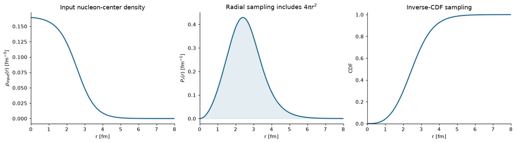

## 2. Sample the two ensembles once

The outputs have shapes $(N_{\rm event},16,3)$ and $(N_{\rm event},16)$. Alpha nucleons retain their cluster IDs after rotation and recentering; the sampler keeps their array order. Exactly two protons belong to every alpha cluster. All subsequent views of an event reuse these arrays.

| Model | Events | RMS radius over all centers [fm] | Smallest pair distance [fm] |
| --- | --- | --- | --- |
| WS / 3pF | 4000 | 2.66062 | 0.50000 |
| alpha | 4000 | 2.68531 | 0.50018 |

### Why the final radial distribution can differ from the input

The input 3pF function describes independent proposals. Rejecting an entire event with a close pair conditions this distribution; subtracting that event's center of mass changes its radii again. The control below shows each operation on the same proposal pool. Agreement of the raw sample with the input is a sampler check. Exact agreement of the final recentered ensemble with the input is not an expected invariant.

```
Control proposals accepted: 2846/4000 (71.2%); raw empirical CDF discrepancy 0.0021
```

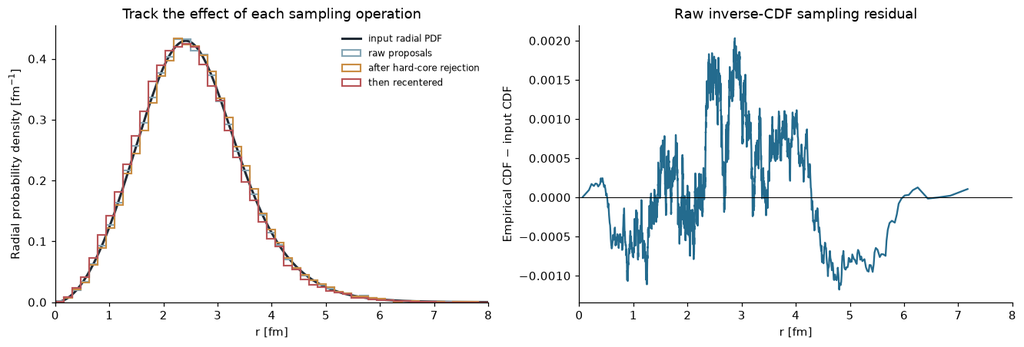

## 3. Tetrahedron and rotations

The ideal vertices have radius $R_\alpha$ and common edge length $\sqrt{8/3}\,R_\alpha$. The actual four-nucleon cluster means fluctuate around the construction centers. The sampler returns nucleons, not its original construction centers; dashed tetrahedra on sampled events connect **observed cluster means**, which need not form a regular tetrahedron.

A uniform orientation requires uniform $\cos\theta$ and azimuth, not uniform $\theta$. The rotation checks also verify $R^\mathsf{T}R=I$ and $\det R=+1$.

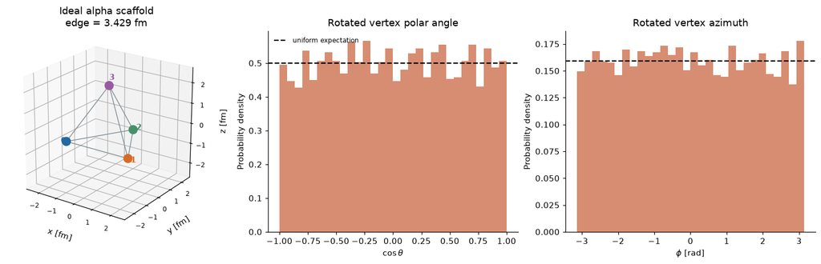

```
Rotation diagnostic: mean direction [ 0.0022 -0.0099  0.0056] ; second moments [0.3375 0.3347 0.3278] (expected 0 and 1/3).
```

## 4. One event in 3D, viewed from three directions

Both rows use the same physical axis scale. Circles are protons, triangles are neutrons. Alpha colors identify the four parent clusters; WS colors distinguish protons and neutrons. Changing the camera preserves the sampled configuration. The black plus marks the nuclear center of mass.

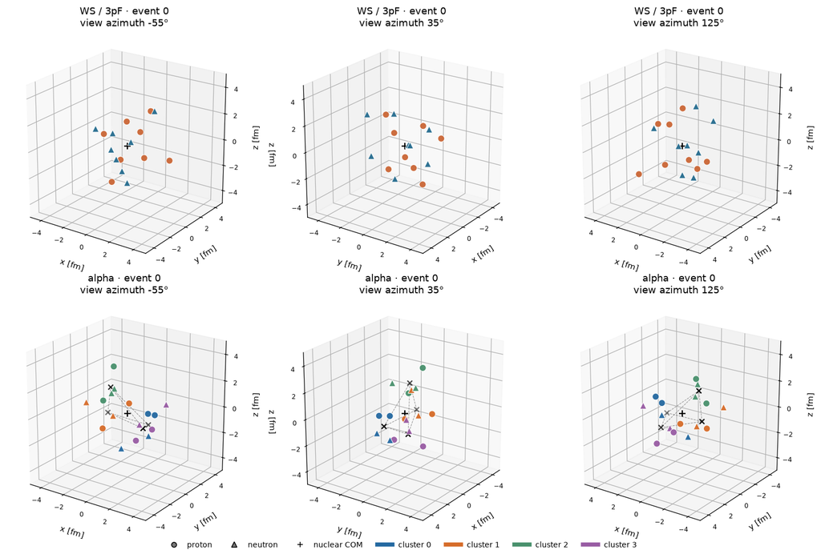

### All three Cartesian projections

These are projections of the same 3D centers onto XY, XZ, and YZ. In particular, two centers may overlap in XY while remaining far apart in 3D. The dashed alpha connections again join observed cluster means.

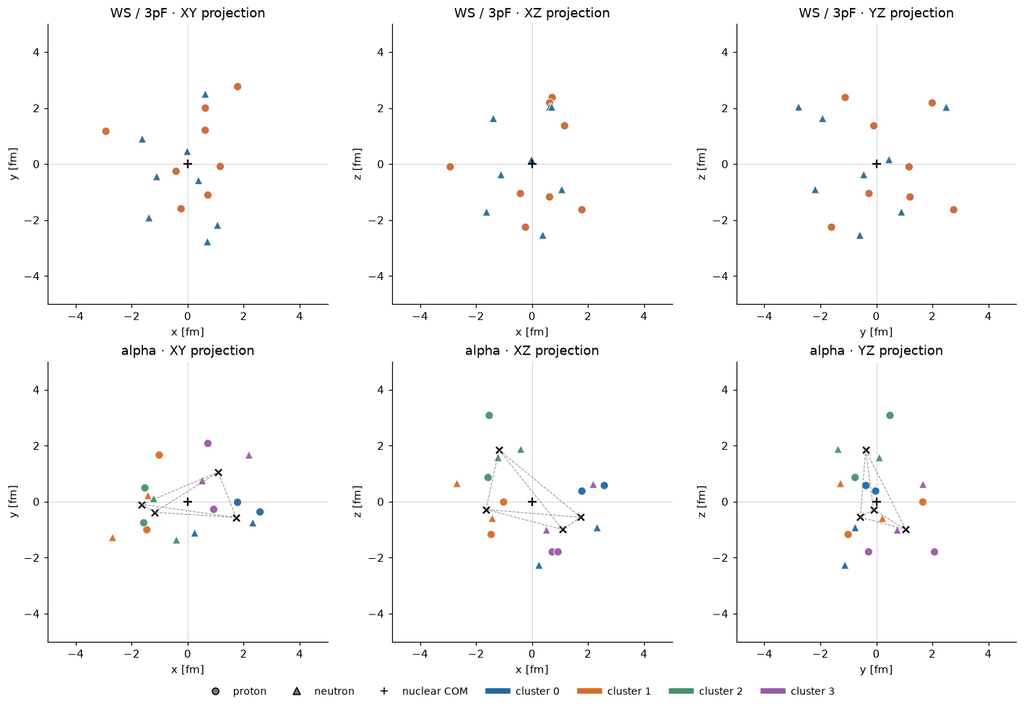

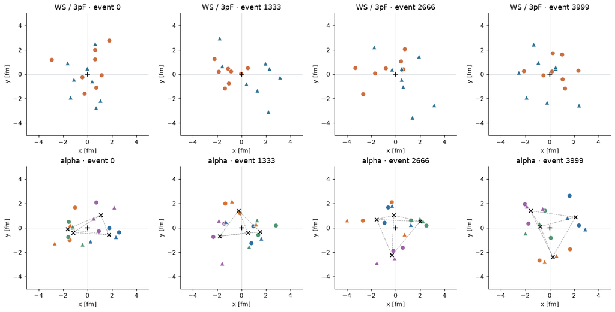

## 5. Ensemble radii, orientation, and shape fluctuations

All histograms in this section use **nucleon centers**. A Gaussian matter profile adds its own width: for unit weights, $\langle r^2\rangle_{\rho}=\langle r_{\rm center}^2\rangle+3\sigma_N^2$ and $\langle b^2\rangle_T=\langle b_{\rm center}^2\rangle+2\sigma_N^2$. Keep this difference in mind when comparing a plotted field radius with a histogram of center radii.

An isotropic ensemble should have matching $x,y,z$ distributions and uniform $z/r$. An individual event can be strongly anisotropic.

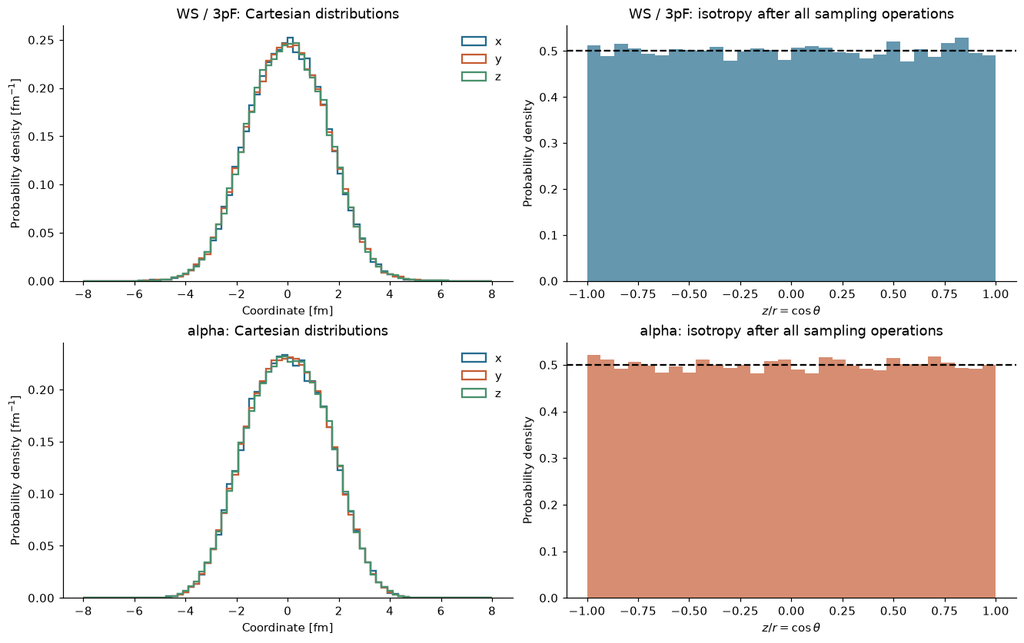

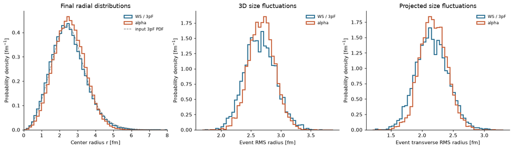

For the following geometric diagnostics, $\varepsilon_n=|\sum_j(x_j+i y_j)^n|/\sum_j b_j^n$ for $n=2,3$. These are recentered, unit-weight **point-nucleon** moments; they are not flow coefficients or dipole amplitudes. A charge-only center of mass can fluctuate away from the nuclear center because it uses only eight of the sixteen nucleons.

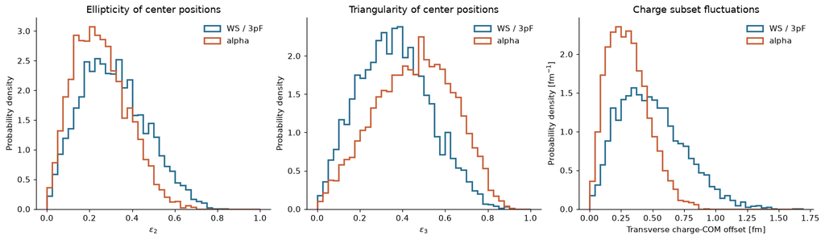

## 6. Hard-core and cluster-distance diagnostics

The exclusion distance applies to **3D nucleon pairs**, including pairs in different alpha clusters. It creates no minimum allowed projected separation. The same-cluster and different-cluster curves below each integrate to one; their pair counts differ, so they should not be added without pair-count weights.

```
WS / 3pF: 2.12% of projected pairs are closer than the 3D exclusion distance (allowed).
alpha: 2.05% of projected pairs are closer than the 3D exclusion distance (allowed).
```

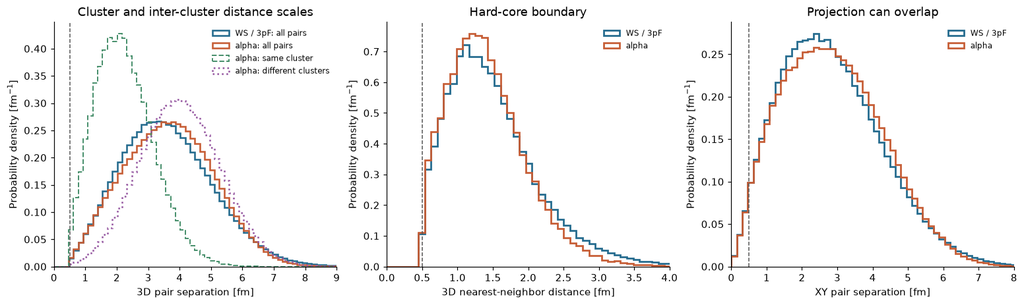

## 7. Attach hotspots to the sampled nucleons

For each event the engine returns hotspot centers $(M,3)$, parent IDs $(M,)$, weights $(M,)$, and positive multiplicities $(16,)$. The number of hotspots $M$ fluctuates. Every parent contributes total weight one, so the target weight remains $A=16$.

The three-dimensional offsets use $\sigma_{\rm offset}=\sqrt{B_p}$ after unit conversion. Each hotspot later receives the narrower Gaussian profile $\sigma_{\rm hs}=\sqrt{B_{\rm hs}}$. No extra recentering or hard-core exclusion is applied to hotspots.

| Model | Hotspots in example | Counts per nucleon | Total target weight |
| --- | --- | --- | --- |
| WS / 3pF | 131 | [7, 8, 12, 7, 6, 12, 3, 11, 8, 14, 7, 6, 9, 5, 4, 12] | 16.000000000000 |
| alpha | 128 | [8, 11, 7, 7, 8, 6, 10, 11, 5, 11, 8, 6, 2, 8, 10, 10] | 16.000000000000 |

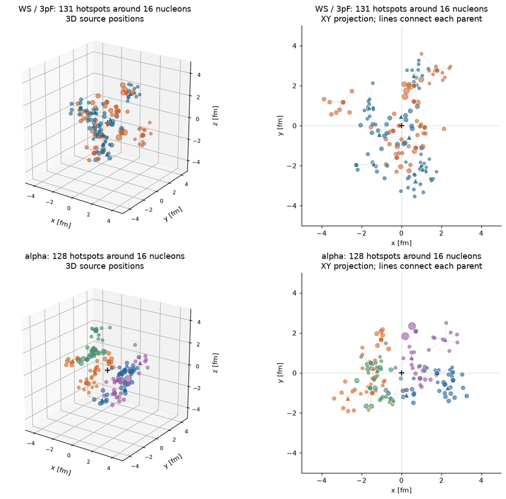

### Multiplicity and width diagnostics

The function `mean_hotspot_count` returns the underlying Poisson rate $\lambda(x)$. The **conditional** mean after rejecting zero is $\mu=\lambda/(1-e^{-\lambda})$. Its variance is $(\lambda+\lambda^2)/(1-e^{-\lambda})-\mu^2$. The offset distributions must instead have variance $B_p$ in each coordinate. The weighted hotspot center of mass is allowed to fluctuate around the nuclear center; forcing it to zero would alter the event fluctuations.

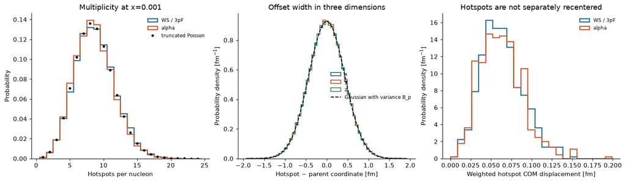

| Statistic | Measured | Expected |
| --- | --- | --- |
| Count mean, WS / 3pF | 8.73535 ± 0.03275 (standard error) | 8.64594 |
| Count mean, alpha | 8.58679 ± 0.03230 (standard error) | 8.64594 |
| Offset means x,y,z [fm] | [-0.001685, -0.000104, -0.001104] | 0, 0, 0 |
| Offset variances x,y,z [fm²] | [0.184515, 0.184159, 0.184296] | 0.184955 each |

```
Offset-mean deviations in nominal standard errors: [-1.48 -0.09 -0.97]
```

### Energy parameter scan on fixed nucleon configurations

The scan changes the hotspot distribution through $\lambda(x)=p_0x^{p_1}(1+p_2\sqrt{x})$. Each displayed $x$ uses one independent hotspot realization around the **same** nucleons. Thus a single pixel or peak need not change monotonically with $x$. Every map still has total target weight 16. For the small-rate control, the difference between the underlying and zero-truncated distributions is especially visible.

The hotspot parameterization is documented in the engine and in [the model reference, equations 10–14](https://arxiv.org/html/2312.11320v2#S2). The values displayed here always come from the repository's parameter objects.

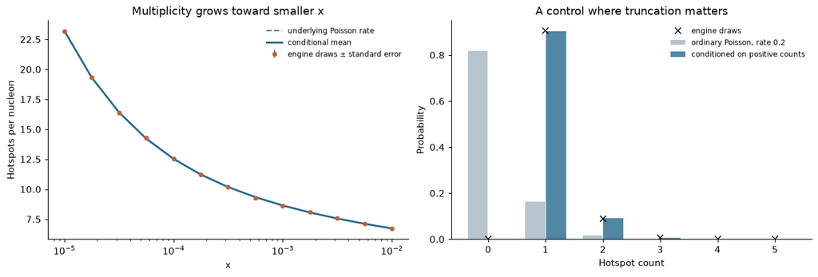

## 8. Gaussian fields: density slices and integrated thickness

For a fixed set of centers $\mathbf r_k=(\mathbf b_k,z_k)$, $$ \rho(\mathbf r)=\sum_k\frac{w_k}{(2\pi\sigma^2)^{3/2}} e^{-|\mathbf r-\mathbf r_k|^2/(2\sigma^2)},\qquad T(\mathbf b)=\sum_k\frac{w_k}{2\pi\sigma^2} e^{-|\mathbf b-\mathbf b_k|^2/(2\sigma^2)}. $$ Both full integrals equal $\sum_k w_k=A$. The transverse exponent and the two-dimensional normalization already include the analytic integration over $z$. Each source's $z_k$ therefore disappears from the thickness.

Each pair of model rows uses shared color scales for the same quantity and profile mode. Density and thickness have separate color scales because their units differ. The plotted window includes at least six smooth-profile widths outside the example source centers.

```
Main map extent ±6 fm; spacing 0.0667 fm; hotspot sigma 0.1765 fm.
```

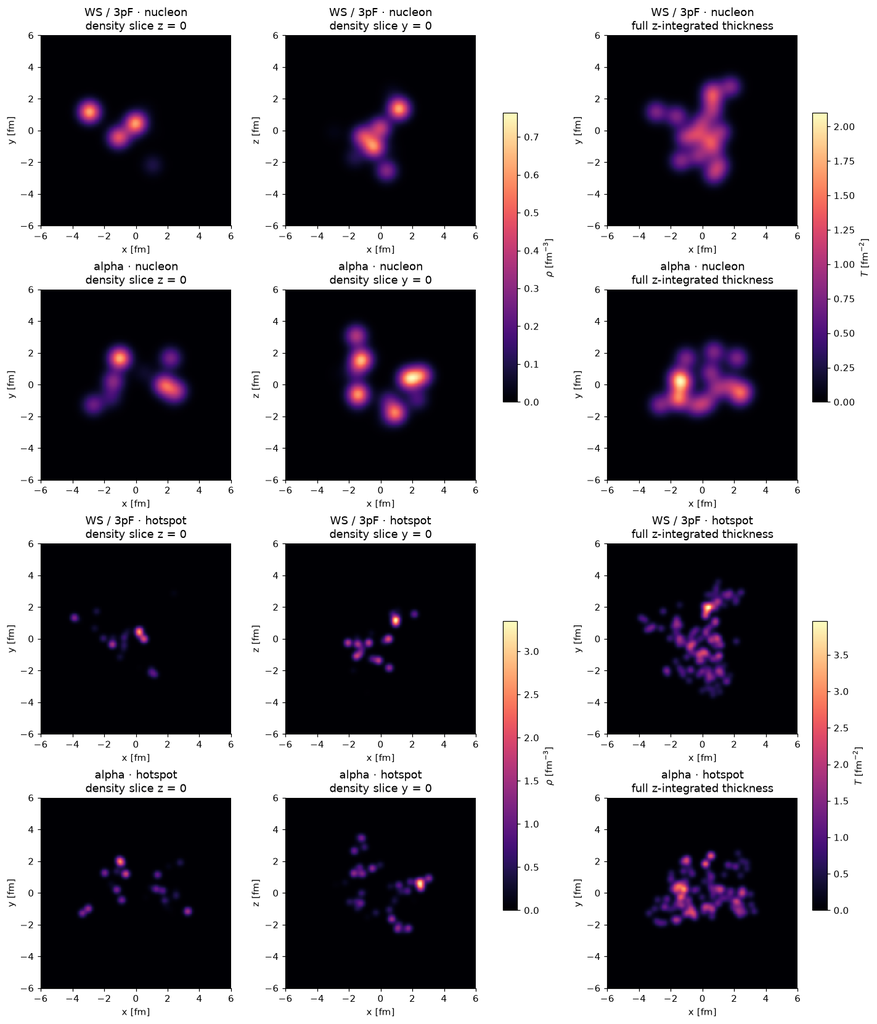

### Thickness as a surface

The vertical coordinate in these plots is **thickness**, in fm$^{-2}$; it is not the physical longitudinal coordinate $z$. Section 12's density-volume explorer uses physical $x,y,z$ coordinates.

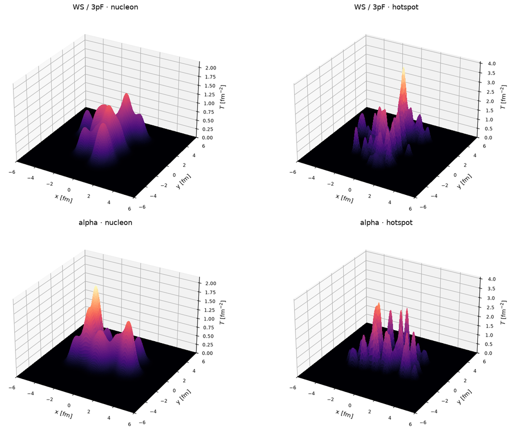

### Follow the density through several longitudinal slices

Moving a slice through $z$ selects different parts of a fixed event. In contrast, the thickness includes every slice. All panels in each profile-mode group share one density color scale.

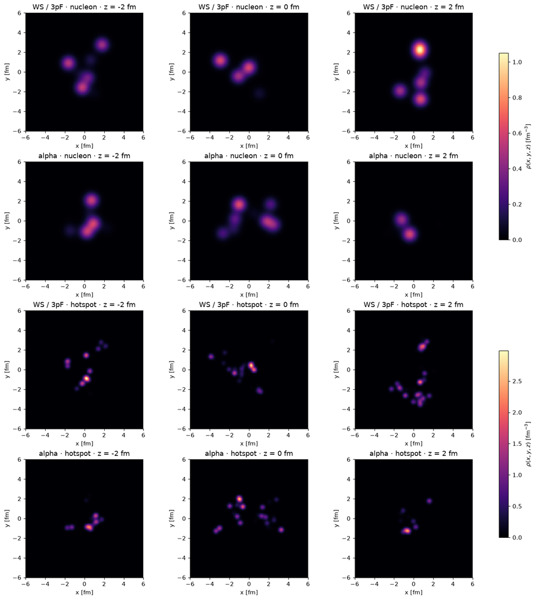

### Projection changes under a physical rotation

Here the **configuration** is rotated, while the beam direction stays along $z$. Nucleons and their already sampled hotspots rotate together. This can change the thickness because a different 3D column is projected. It differs from merely moving the 3D camera, and from rotating the whole image within the XY plane.

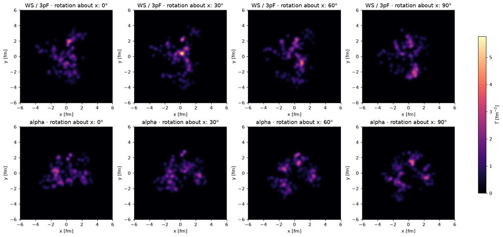

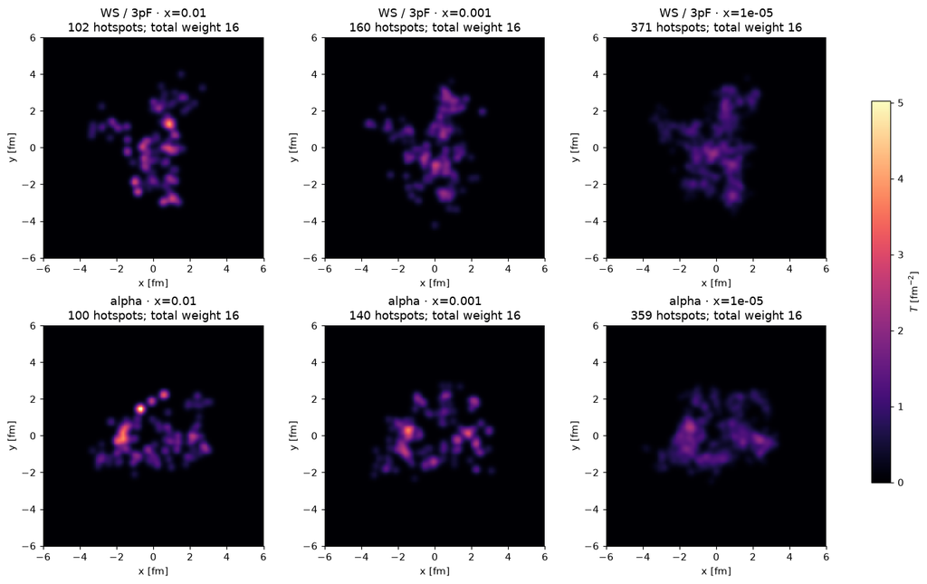

## 9. Integrate the actual 3D density over z

This numerical calculation evaluates `position_to_gaussian_density` on $(x,y,z)$ points and integrates its output with the trapezoid rule. It is independent of the analytic thickness evaluator. The $z$ interval extends eight profile widths beyond every source center; the grid is refined from roughly $2\sigma$ to $\sigma/2$.

The left panels show a longitudinal density column through the highest-thickness pixel of each example. The right panels compare analytic and numerical thickness along $y=0$. The area under a left-hand curve is a thickness, not a 3D density.

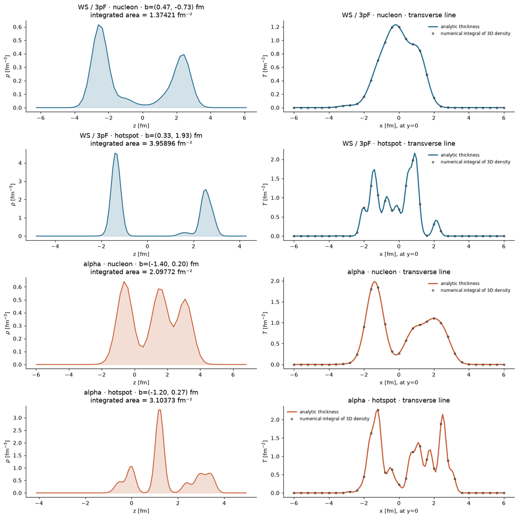

### Separate longitudinal window loss from grid-spacing error

A coarse grid can miss a narrow Gaussian even when its integration window is large. A fine grid with too small a window instead loses genuine Gaussian tails. The window-loss curves below use exact Gaussian CDFs at the selected columns; the spacing curves use numerical integration of the engine's 3D density. Very small errors are shown at a plotting floor of $10^{-16}$.

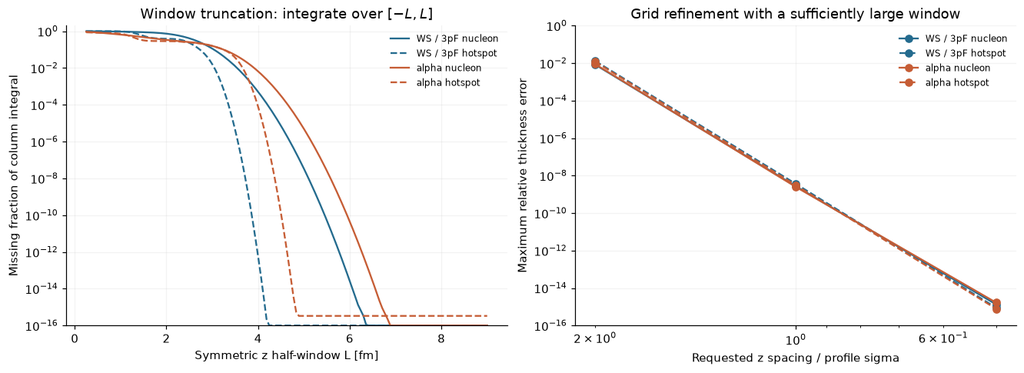

## 10. Full normalization and transformation audit

The next cell integrates the engine's 3D density on a Cartesian volume, then compares it with a transverse integral of its thickness. Each volume extends seven profile widths beyond all centers, with spacing no larger than $\sigma/2$. An independent finite-box Gaussian-CDF result distinguishes quadrature error from the tiny amount of probability outside the box.

This is the most expensive validation cell. It evaluates points in chunks so a large points-by-sources-by-coordinates array is never allocated for the full volume.

```
WS / 3pF nucleon: volume 15.999999999985; thickness 15.999999999977; volume grid (50, 53, 51)
```

```
WS / 3pF hotspot: volume 15.999999999998; thickness 16.000000000000; volume grid (101, 110, 101)
alpha nucleon: volume 15.999999999985; thickness 15.999999999999; volume grid (52, 44, 52)
```

```
alpha hotspot: volume 15.999999999998; thickness 16.000000000000; volume grid (105, 80, 100)
```

| Model | Mode | 3D integral | 2D integral | Exact finite 3D box |
| --- | --- | --- | --- | --- |
| WS / 3pF | nucleon | 15.99999999999 | 15.99999999998 | 15.99999999999 |
| WS / 3pF | hotspot | 16.00000000000 | 16.00000000000 | 16.00000000000 |
| alpha | nucleon | 15.99999999998 | 16.00000000000 | 15.99999999999 |
| alpha | hotspot | 16.00000000000 | 16.00000000000 | 16.00000000000 |

### Transverse resolution check

Coarse sampling can both overestimate and underestimate a narrow Gaussian, depending on the phase of the grid relative to its centers. The two grid origins below expose this aliasing. The fine-grid result should approach the independent finite-window integral for both choices. This is separate from the resolution of the illustrative 3D explorer.

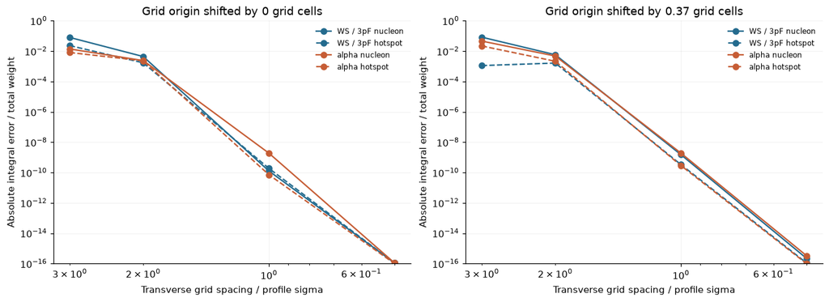

## 11. Ensemble mean and fluctuations of the thickness

The maps below reuse the first field-ensemble events of each model. Smooth and hotspot profiles use exactly the same underlying nucleons. The right column shows the **sample standard deviation of the hotspot thickness across events**, not the standard error of its mean and not an incoherent cross section.

Finite samples need not give perfectly circular mean maps. The two models are rotationally invariant as ensembles even though their individual events are not.

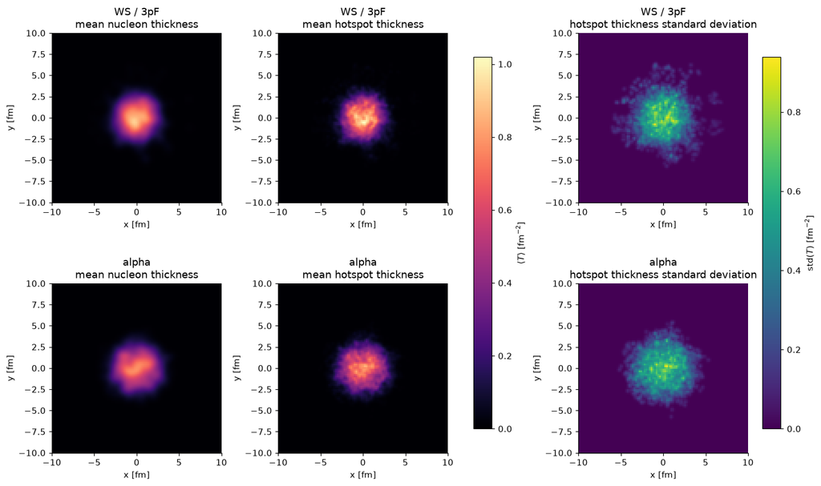

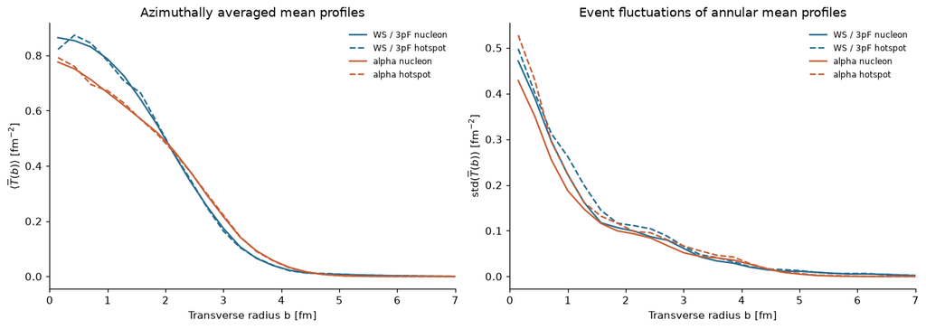

### Hotspot averaging at fixed nucleon positions

This control holds the nucleons fixed and averages independent hotspot realizations. Because every parent carries unit weight, the ensemble mean is the Gaussian convolution with variance $B_p+B_{\rm hs}$, irrespective of the sampled hotspot count. The finite-sample residual should shrink statistically as more independent configurations are added; it need not decrease at every step. This explains the smooth-width convention chosen at the top of the notebook.

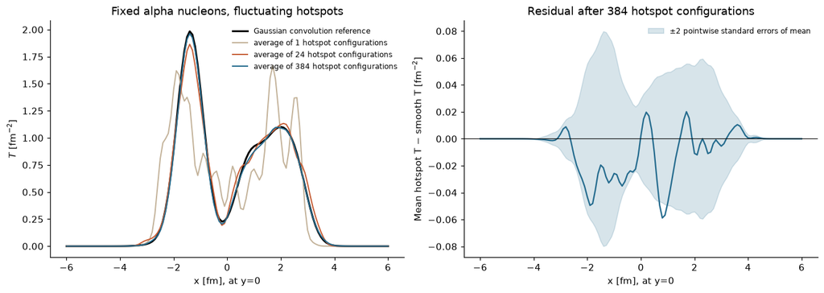

## 12. Rotatable 3D explorers

The two standalone HTML files work without a running notebook kernel or an internet connection. Drag to rotate, scroll to zoom, and hover for coordinates. Both model panels use matching physical axis scales. Use the standalone links for a full-size view, including in notebook frontends that restrict embedded local HTML.

The first explorer shows sampled nucleons and hotspots, with optional parent-connection lines. In this interactive view, circles denote protons and diamonds denote neutrons. Alpha colors identify the four clusters.

The second explorer shows **isosurfaces of the summed 3D smooth density** for both geometries. Its vertical axis is physical $z$. The surface levels and color scale are common to the two models. Hotspot density structure is resolved in the static slice plots above; hotspot centers are rotatable in the first explorer. The volume grid is for illustration, and is independent of the finer integration grids used in the audit.

**Open the rotatable nucleon and hotspot explorer**

[interactive chart not shown]

**Open the rotatable 3D density explorer**

[interactive chart not shown]

## 13. Audit results and saved debugging data

The table reports deterministic invariants and numerical tolerances for the configured parameter set. Statistical distributions are shown with their expected means or reference curves; finite Monte Carlo noise is not treated as a code error.

The export contains:

- every static figure as a PNG;
- the two standalone interactive HTML explorers, if Plotly is available;
- an NPZ snapshot of both nucleon ensembles, proton masks, packed hotspot configurations, and the example density/thickness maps;
- a JSON manifest with parameters, seed, source-file hashes, and check results.

The snapshot's hotspot event offsets index concatenated arrays; parent IDs are local nucleon indices 0–15 within each event. All saved coordinates are in fm.

**59/59 checks passed**

| Check | Result | Evidence |
| --- | --- | --- |
| 3pF density normalization | PASS | integral=15.999999999999 |
| 3pF CDF endpoints and monotonicity | PASS | CDF rises from 0 to 1 |
| WS / 3pF: output shapes | PASS | (4000, 16, 3), (4000, 16) |
| WS / 3pF: finite coordinates | PASS | all finite |
| WS / 3pF: centered events | PASS | max coordinate COM=4.86e-16 fm |
| WS / 3pF: eight protons | PASS | all events |
| WS / 3pF: 3D hard core | PASS | minimum=0.500001 fm |
| alpha: output shapes | PASS | (4000, 16, 3), (4000, 16) |
| alpha: finite coordinates | PASS | all finite |
| alpha: centered events | PASS | max coordinate COM=4.44e-16 fm |
| alpha: eight protons | PASS | all events |
| alpha: 3D hard core | PASS | minimum=0.500178 fm |
| Alpha: two protons per cluster | PASS | all four clusters in every event |
| Regular tetrahedron radii and edges | PASS | edge length=3.429286 fm |
| Rotations are proper orthogonal matrices | PASS | R.T R=I; det R=+1 |
| WS / 3pF: hotspot shapes | PASS | M=sum(counts); centers (M,3); IDs and weights (M,) |
| WS / 3pF: positive counts and parent IDs | PASS | bincount(parent IDs)=counts |
| WS / 3pF: hotspot parent and target weights | PASS | each parent sums to 1; each event sums to 16 |
| alpha: hotspot shapes | PASS | M=sum(counts); centers (M,3); IDs and weights (M,) |
| alpha: positive counts and parent IDs | PASS | bincount(parent IDs)=counts |
| alpha: hotspot parent and target weights | PASS | each parent sums to 1; each event sums to 16 |
| Zero-truncated Poisson small-rate control | PASS | 25,000 draws at rate 0.2; no zeros |
| WS / 3pF nucleon: numerical z integral | PASS | max relative error above 1e-8 of peak=1.33e-15 |
| WS / 3pF hotspot: numerical z integral | PASS | max relative error above 1e-8 of peak=8.88e-16 |
| alpha nucleon: numerical z integral | PASS | max relative error above 1e-8 of peak=1.67e-15 |
| alpha hotspot: numerical z integral | PASS | max relative error above 1e-8 of peak=7.77e-16 |
| WS / 3pF nucleon: 3D volume integral | PASS | numerical=15.999999999985; finite-box exact=15.999999999992 |
| WS / 3pF nucleon: transverse integral | PASS | integral=15.999999999977; expected=16 |
| WS / 3pF hotspot: 3D volume integral | PASS | numerical=15.999999999998; finite-box exact=15.999999999999 |
| WS / 3pF hotspot: transverse integral | PASS | integral=16.000000000000; expected=16 |
| alpha nucleon: 3D volume integral | PASS | numerical=15.999999999985; finite-box exact=15.999999999992 |
| alpha nucleon: transverse integral | PASS | integral=15.999999999999; expected=16 |
| alpha hotspot: 3D volume integral | PASS | numerical=15.999999999998; finite-box exact=15.999999999999 |
| alpha hotspot: transverse integral | PASS | integral=16.000000000000; expected=16 |
| WS / 3pF nucleon: 3D covariance | PASS | rotate or translate both the query points and all centers |
| WS / 3pF nucleon: thickness covariance and longitudinal invariance | PASS | in-plane rotations preserve values; shifting centers along z preserves full integrals |
| WS / 3pF hotspot: 3D covariance | PASS | rotate or translate both the query points and all centers |
| WS / 3pF hotspot: thickness covariance and longitudinal invariance | PASS | in-plane rotations preserve values; shifting centers along z preserves full integrals |
| alpha nucleon: 3D covariance | PASS | rotate or translate both the query points and all centers |
| alpha nucleon: thickness covariance and longitudinal invariance | PASS | in-plane rotations preserve values; shifting centers along z preserves full integrals |
| alpha hotspot: 3D covariance | PASS | rotate or translate both the query points and all centers |
| alpha hotspot: thickness covariance and longitudinal invariance | PASS | in-plane rotations preserve values; shifting centers along z preserves full integrals |
| Single-source 3D and 2D peak normalizations | PASS | known Gaussian peaks, including an off-plane source |
| WS / 3pF: seed reproducibility | PASS | replaying the first three events reproduces coordinates and proton masks exactly |
| WS / 3pF: hotspot seed reproducibility | PASS | all four hotspot outputs reproduce exactly |
| alpha: seed reproducibility | PASS | replaying the first three events reproduces coordinates and proton masks exactly |
| alpha: hotspot seed reproducibility | PASS | all four hotspot outputs reproduce exactly |
| WS / 3pF nucleon: fine XY quadrature, phase 0.0 | PASS | relative integration error=1.11e-16 |
| WS / 3pF nucleon: fine XY quadrature, phase 0.37 | PASS | relative integration error=2.22e-16 |
| WS / 3pF hotspot: fine XY quadrature, phase 0.0 | PASS | relative integration error=1.11e-16 |
| WS / 3pF hotspot: fine XY quadrature, phase 0.37 | PASS | relative integration error=1.11e-16 |
| alpha nucleon: fine XY quadrature, phase 0.0 | PASS | relative integration error=1.11e-16 |
| alpha nucleon: fine XY quadrature, phase 0.37 | PASS | relative integration error=3.33e-16 |
| alpha hotspot: fine XY quadrature, phase 0.0 | PASS | relative integration error=0 |
| alpha hotspot: fine XY quadrature, phase 0.37 | PASS | relative integration error=0 |
| WS / 3pF nucleon: ensemble mean normalization | PASS | mean map integral=16.0000000000 |
| WS / 3pF hotspot: ensemble mean normalization | PASS | mean map integral=16.0000000565 |
| alpha nucleon: ensemble mean normalization | PASS | mean map integral=16.0000000000 |
| alpha hotspot: ensemble mean normalization | PASS | mean map integral=15.9999999053 |

```
Saved 24 static figures and 2 interactive explorers.
Snapshot and manifest: /Users/xihehan/asym_upc/notebooks/geometry_debug_outputs
Elapsed time: 27.2 s
```

## 14. How to use this notebook while developing

**Change one control, then Run All.** Use a different seed or event index to check that a feature is not specific to one example. Increase the geometry ensemble for the radial and pair statistics; increase the field ensemble for the mean and fluctuation maps. Increase spatial resolution when investigating narrow hotspot structure.

**Use the appropriate invariant.** Nuclear COM and per-parent hotspot weight are exact constraints. Radial distributions can change after hard-core rejection and recentering. Hotspot COM can fluctuate. Projected pairs can overlap. The smooth and hotspot fields coincide only after the appropriate ensemble average with the chosen convolution width.

**Keep the layers separate.** Nucleon sampling widths, hotspot offset widths, and source-profile widths describe different steps. A density slice uses fm$^{-3}$; thickness uses fm$^{-2}$ and integrates to $A$. The maps in this notebook provide geometry for the later GBW and finite-$A$ opacity calculation. They are not scattering amplitudes or coherent/incoherent cross sections.